# General Mills Cereal Sales Analysis

Eric Hestekin, Schyuler Lujan

2/13/2020

Repo: https://github.com/ehestekin/MSBA_5210_DataVis

```r
# Turn off scientific notation
options(scipen = 999)
```

# 1 Introduction to research

## 1.1 Initial expectations / biases

- Not expecting significant seasonal trends, since cereal is a household staple
- Less expensive cereals sell more, more expensive cereals sell less
- More expensive cereals will sell more with promotions relative to without promotions

# 2 Load data and get initial summary

```r
# Load sales data
sales_df <- read.csv("mtp_sales_data.csv")
# Load product data
product_df <- read.csv("mtp_product_data.csv")
```

# 3 Uni-variate non-graphical analysis

## 3.1 Look at first 10 rows

```r
# Look at first 10 rows of sales_df
head(sales_df, 10)
```

```
##               UPC iri_key week units price promo   ad
## 1  01.16000.11653  644347    6     5  0.50     0    A
## 2  01.16000.11653  248741    5     2  0.50     0 NONE
## 3  01.16000.11653  535806   11     3  0.50     0 NONE
## 4  01.16000.11945  675634   11     2  0.50     0 NONE
## 5  01.16000.11945  205272   13     8  0.50     0 NONE
## 6  01.16000.11945  248741   14     5  0.50     0 NONE
## 7  01.16000.14154  932600   39     6  1.09     0 NONE
## 8  01.16000.14154  278738   35     1  1.59     0 NONE
## 9  01.16000.14154  660222   45     4  1.59     0 NONE
## 10 01.16000.14154  644937    5    14  1.00     0 NONE
```

```r
# Look at first 10 rows of product_df
head(product_df, 10)
```

```
##                  UPC                         brand         flavor volume
## 1  00-01-16000-11653 GENERAL MILLS CINNAMON TST CR CINNAMON TOAST   0.06
## 2  00-01-16000-11945        GENERAL MILLS CHEERIOS        TOASTED   0.04
## 3  00-01-16000-14154 GENERAL MILLS CINNAMON TST CR CINNAMON TOAST   0.12
## 4  00-01-16000-14156    GENERAL MILLS LUCKY CHARMS        TOASTED   0.11
## 5  00-01-16000-14159        GENERAL MILLS CHEERIOS        TOASTED   0.08
## 6  00-01-16000-16179     GENERAL MILLS COCOA PUFFS          COCOA   0.89
## 7  00-01-16000-16181 GENERAL MILLS CINNAMON TST CR CINNAMON TOAST   0.98
## 8  00-01-16000-16182    GENERAL MILLS LUCKY CHARMS        TOASTED   0.87
## 9  00-01-16000-27507 GENERAL MILLS CINNAMON TST CR CINNAMON TOAST   0.80
## 10 00-01-16000-27509    GENERAL MILLS LUCKY CHARMS        TOASTED   1.50
##    package
## 1      BOX
## 2      BOX
## 3      CUP
## 4      CUP
## 5      CUP
## 6      BOX
## 7      BOX
## 8      BOX
## 9      BOX
## 10     BOX
```

**sales_df**

- `UPC` formatting has periods rather than dashes, so many need cleanup before joining tables
- `iri_key` is the store identifier, so rename later to make it clear

**product_df**

- check if `UPC` variable in `product_df` is unique for that table before joining
- possibly pull text from `brand` variable to separate cereal from brand for cleaner groupings

## 3.2 Look at structure

```r
# Look at structure of sales_df
str(sales_df)
```

```
## 'data.frame':    21850 obs. of  7 variables:
##  $ UPC    : Factor w/ 114 levels "01.16000.11653",..: 1 1 1 2 2 2 3 3 3 3 ...
##  $ iri_key: int  644347 248741 535806 675634 205272 248741 932600 278738 660222 644937 ...
##  $ week   : int  6 5 11 11 13 14 39 35 45 5 ...
##  $ units  : int  5 2 3 2 8 5 6 1 4 14 ...
##  $ price  : num  0.5 0.5 0.5 0.5 0.5 0.5 1.09 1.59 1.59 1 ...
##  $ promo  : int  0 0 0 0 0 0 0 0 0 0 ...
##  $ ad     : Factor w/ 3 levels "A","B","NONE": 1 3 3 3 3 3 3 3 3 3 ...
```

```r
# Look at structure of product_df
str(product_df)
```

```
## 'data.frame':    114 obs. of  5 variables:
##  $ UPC    : Factor w/ 114 levels "00-01-16000-11653",..: 1 2 3 4 5 6 7 8 9 10 ...
##  $ brand  : Factor w/ 15 levels "GENERAL MILLS CHEERIOS",..: 2 1 2 5 1 3 2 5 2 5 ...
##  $ flavor : Factor w/ 5 levels "CINNAMON TOAST",..: 1 5 1 5 5 2 1 5 1 5 ...
##  $ volume : num  0.06 0.04 0.12 0.11 0.08 0.89 0.98 0.87 0.8 1.5 ...
##  $ package: Factor w/ 2 levels "BOX","CUP": 1 1 2 2 2 1 1 1 1 1 ...
```

```r
# Count number of unique UPC on both data frames
n_distinct(sales_df$UPC)
```

```
## [1] 114
```

```r
n_distinct(product_df$UPC)
```

```
## [1] 114
```

## 3.3 Data Transformations

```r
# Check if UPC in product_df is unique
sum(duplicated(product_df$UPC))
```

```
## [1] 0
```

```r
# Key cleanup in sales_df: replace periods with dashes
sales_df$UPC <- str_replace_all(sales_df$UPC, "[.]", "-")
# Key cleanup in product_df: remove first three characters
product_df$UPC <- sub("00-", "", product_df$UPC)
# Left join with sales_df as left table to preserve all sales data
full_df <- left_join(sales_df, product_df, by = c("UPC", "UPC"))
# Check for any null values in joined df
sum(is.na(full_df)) # no null values
```

```
## [1] 0
```

```r
# Rename iri_key variable for clarity
full_df <- rename(full_df, "store_key" = iri_key)
# Create new variables;
full_df <- mutate(full_df,
                  company = as.factor(
                    ifelse(str_detect(full_df$brand, "KELLOGGS"), "Kellogg",
                           ifelse(str_detect(full_df$brand, "GENERAL MILLS"), "General Mills", "Post"))),
                  total_sales = (units * price),
                  season = (week %/% 14) + 1,
                  ad2 = ifelse(ad == "NONE", 0, 1))
#Note above is integer division where 14 is number of weeks per season plus 1 so that week 13 is put in the first season (similar with week 52)
# The + 1 after the integer division is so seasons go 1 - 4 instead of 0 - 3

#realized also want total volumes too
full_df <- full_df %>% mutate(total_volume = units * volume)
```

## 3.4 Descriptive Statistics

```r
# View descriptive statistics to assess factor variables
summary(full_df)
```

```
##      UPC              store_key            week           units
##  Length:21850       Min.   : 200171   Min.   : 1.00   Min.   : 1.000
##  Class :character   1st Qu.: 241553   1st Qu.:14.00   1st Qu.: 3.000
##  Mode  :character   Median : 273720   Median :27.00   Median : 7.000
##                     Mean   : 454405   Mean   :26.62   Mean   : 8.579
##                     3rd Qu.: 648547   3rd Qu.:40.00   3rd Qu.:12.000
##                     Max.   :8057418   Max.   :52.00   Max.   :28.000
##
##      price           promo          ad
##  Min.   :0.250   Min.   :0.000   A   : 1456
##  1st Qu.:3.190   1st Qu.:0.000   B   : 1061
##  Median :3.790   Median :0.000   NONE:19333
##  Mean   :3.763   Mean   :0.208
##  3rd Qu.:4.390   3rd Qu.:0.000
##  Max.   :9.990   Max.   :1.000
##
##                            brand                  flavor
##  KELLOGGS FROSTED FLAKES      : 2295   CINNAMON TOAST:1834
##  KELLOGGS FROOT LOOPS         : 2192   COCOA         :1901
##  GENERAL MILLS CINNAMON TST CR: 1834   FRUIT         :2192
##  GENERAL MILLS LUCKY CHARMS   : 1681   REGULAR       :8816
##  KELLOGGS FROSTED MINI WHEATS : 1574   TOASTED       :7107
##  GENERAL MILLS CHEERIOS       : 1458
##  (Other)                      :10816
##      volume      package              company       total_sales
##  Min.   :0.040   BOX:21306   General Mills: 7189   Min.   :  0.48
##  1st Qu.:0.750   CUP:  544   Kellogg      :12183   1st Qu.: 11.80
##  Median :1.060               Post         : 2478   Median : 24.50
##  Mean   :1.016                                     Mean   : 31.01
##  3rd Qu.:1.120                                     3rd Qu.: 44.09
##  Max.   :4.000                                     Max.   :155.48
##
##      season          ad2          total_volume
##  Min.   :1.00   Min.   :0.0000   Min.   : 0.060
##  1st Qu.:2.00   1st Qu.:0.0000   1st Qu.: 2.880
##  Median :2.00   Median :0.0000   Median : 6.400
##  Mean   :2.45   Mean   :0.1152   Mean   : 8.772
##  3rd Qu.:3.00   3rd Qu.:0.0000   3rd Qu.:12.320
##  Max.   :4.00   Max.   :1.0000   Max.   :80.000
##
```

**Initial Observations**

*store_key*

- there are a large number of stores, so grouping by stores may not yield useful results

*units*

- mean slightly higher than the mean with outliers, so skewed to the right
- what are the total units sold by brand?

*price*

- roughly symmetric distribution
- majority of items (75%) are $4.39 or less, regardless of brand
- max price of $9.99 indicates an outlier
- Maybe useful to look at price/volume for a consistent comparable? – Seems to be a wide variety of package sizes which leads to more variety in price/package

*promo*

- majority of sold items (79%) do not have in-store promotions, so must be mindful of sample sizes

*ad*

- majority of sold items (88.48%) don’t have ads

*volume*

- mean and median are about the same; use either as measure of central tendency
- majority of items (75%) are 1.12 or less

*flavor*

- regular and toasted are the top two flavors

*package*

- 97.51% of observations come in a box

# 4 Uni-variate graphical analysis

## 4.1 Quantitative Variables

### 4.1.1 Price

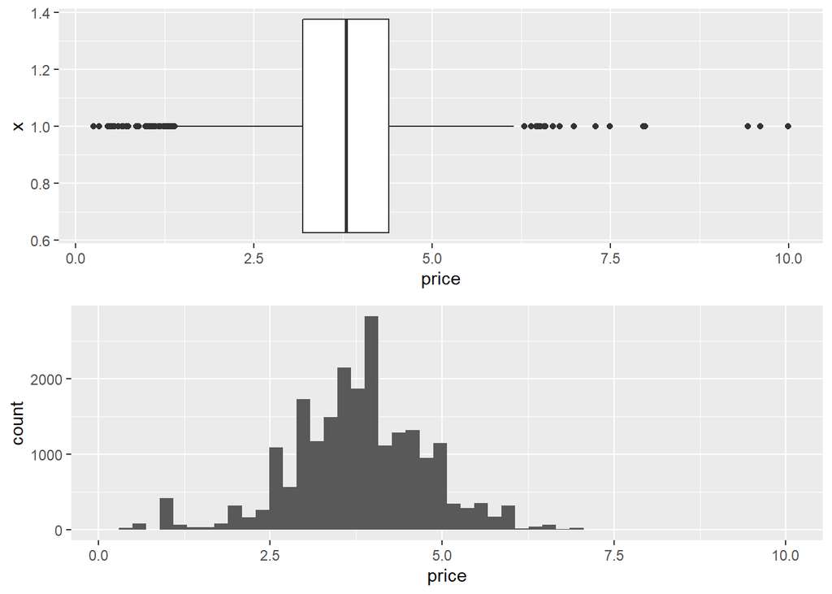

```r
# Price
grid.arrange(
  ggplot(data = full_df, mapping = aes(x = 1, y = price)) +
    geom_boxplot() +
    coord_flip(),

  ggplot(data = full_df, mapping = aes(x = price)) +
    geom_histogram(bins = 50),

  ncol = 1
)
```

### 4.1.2 Price / Volume

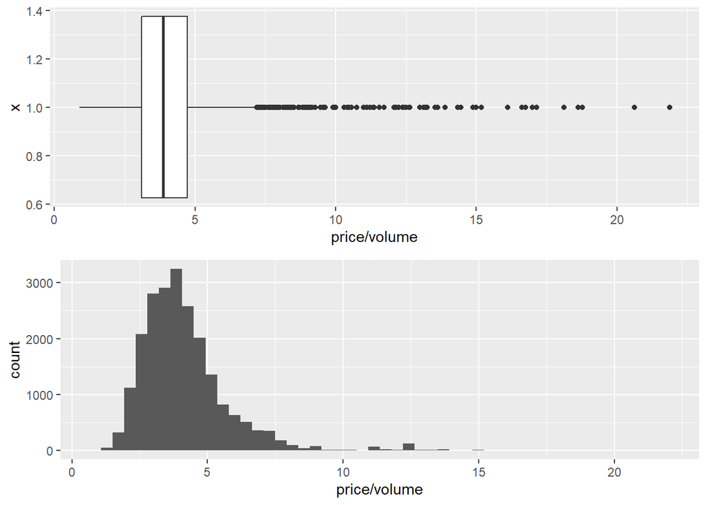

```r
#Compare above to price/volume
# NOTE/TODO: Not positive volume column is consistent unit.  Verify
grid.arrange(
  ggplot(data = full_df, mapping = aes(x = 1, y = price/volume)) +
    geom_boxplot() +
    coord_flip(),

  ggplot(full_df, mapping = aes(x = price/volume)) +
    geom_histogram(bins = 50),

  ncol = 1
)
```

Maybe more symmetrical main distribution, but maybe more outliers. - Due to inconsitent unit of volume?

### 4.1.3 Units

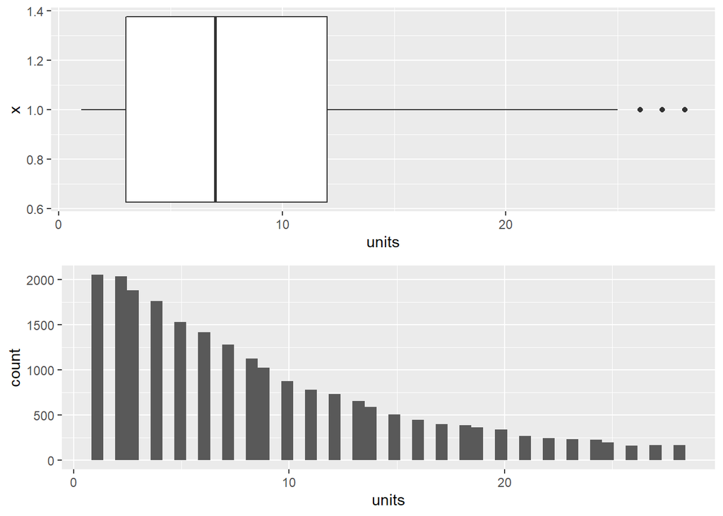

```r
# Units
grid.arrange(
  ggplot(data = full_df, mapping = aes(x = 1, y = units)) +
    geom_boxplot() +
    coord_flip(),

  ggplot(data = full_df, mapping = aes(x = units)) +
    geom_histogram(bins = 50),

  ncol = 1
)
```

Certainly not symmetrical. Makes sense as it implies it’s most common to sell fewer units in a week.

### 4.1.4 Volume

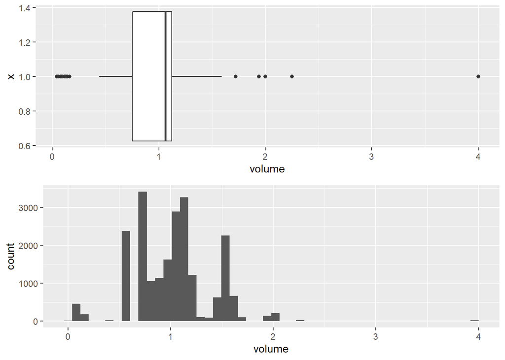

```r
# volume
grid.arrange(
  ggplot(data = full_df, mapping = aes(x = 1, y = volume)) +
    geom_boxplot() +
    coord_flip(),

  ggplot(data = full_df, mapping = aes(x = volume)) +
    geom_histogram(bins = 50),

  ncol = 1
)
```

### 4.1.5 Total Sales

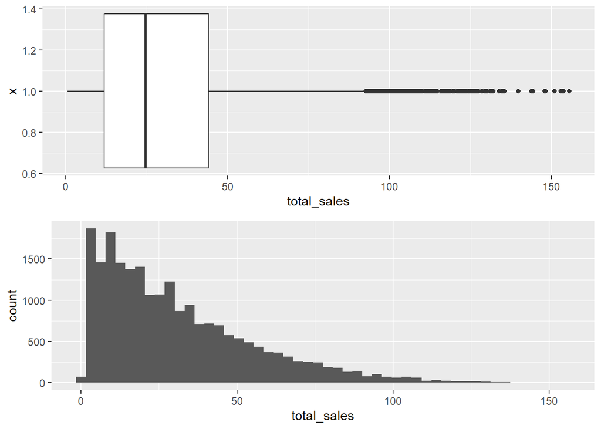

```r
grid.arrange(
ggplot(data = full_df, mapping = aes(x = 1, y = total_sales)) +
  geom_boxplot() +
  coord_flip(),

ggplot(data = full_df, mapping = aes(x = total_sales)) +
  geom_histogram(bins = 50),
nrow = 2)
```

## 4.2 Categorical Variables

### 4.2.1 Brand

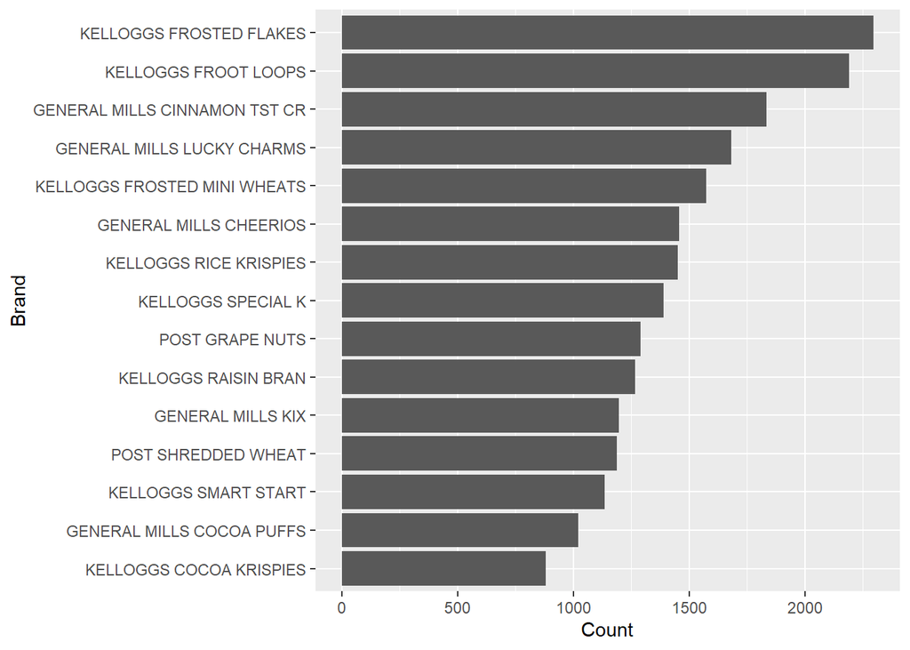

```r
# Count by brand
full_df %>%
  group_by(brand) %>%
  summarize(n_brand = n()) %>%
  ggplot(mapping = aes(x = reorder(brand, n_brand), y = n_brand)) +
  geom_bar(stat = 'identity') +
  xlab('Brand') +
  ylab('Count') +
  coord_flip()
```

### 4.2.2 Flavor

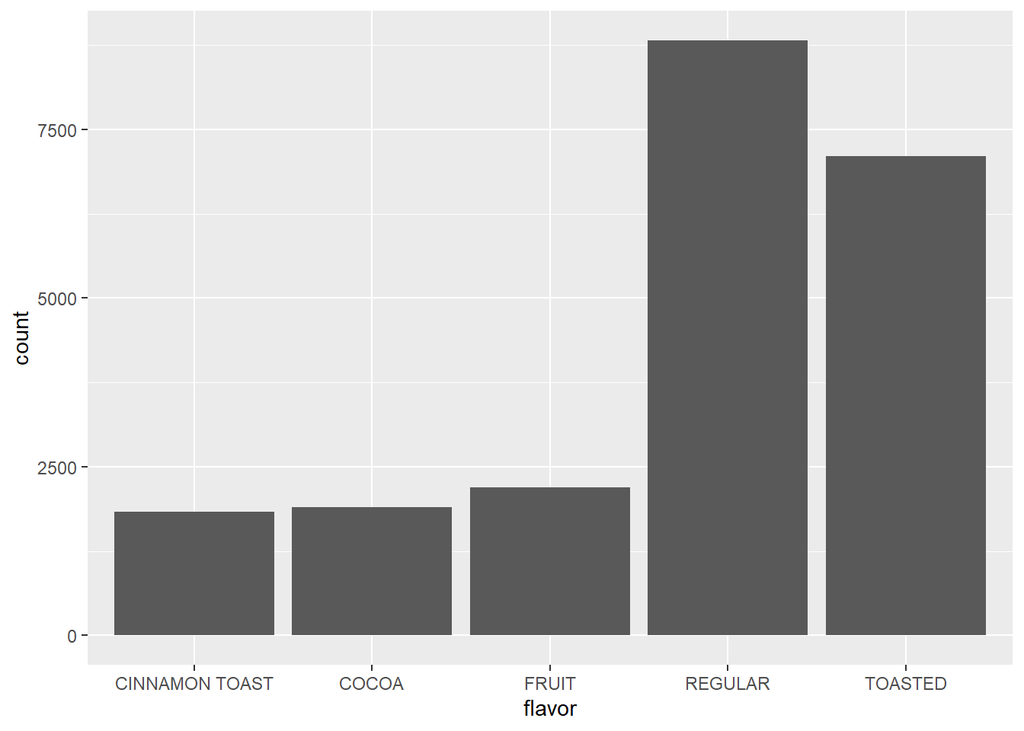

```r
# Count by flavor
ggplot(data = full_df, mapping = aes(x = flavor)) +
  geom_bar()
```

```r
#alternatively
#ggplot(data = full_df, mapping = aes(x = flavor)) +
#   geom_histogram(stat = 'count')
```

### 4.2.3 Company

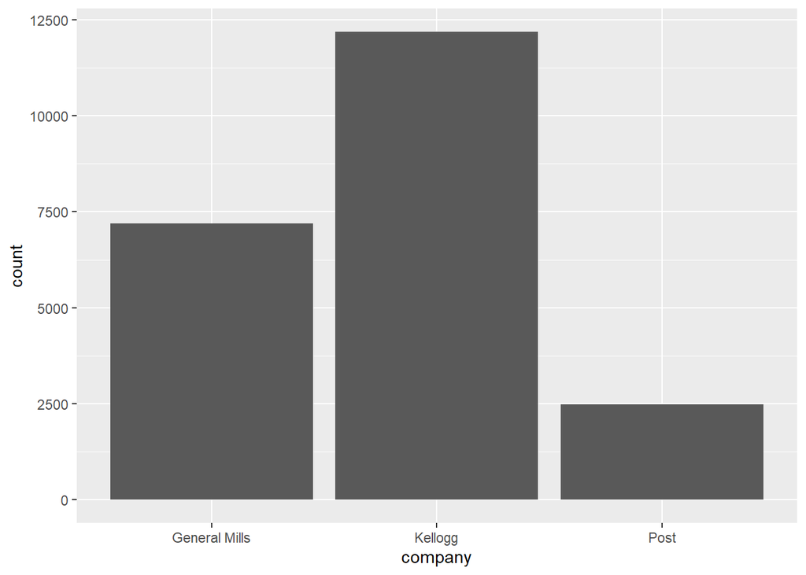

```r
# Count by company
ggplot(data = full_df, mapping = aes(x = company)) +
  geom_bar()
```

### 4.2.4 Ads

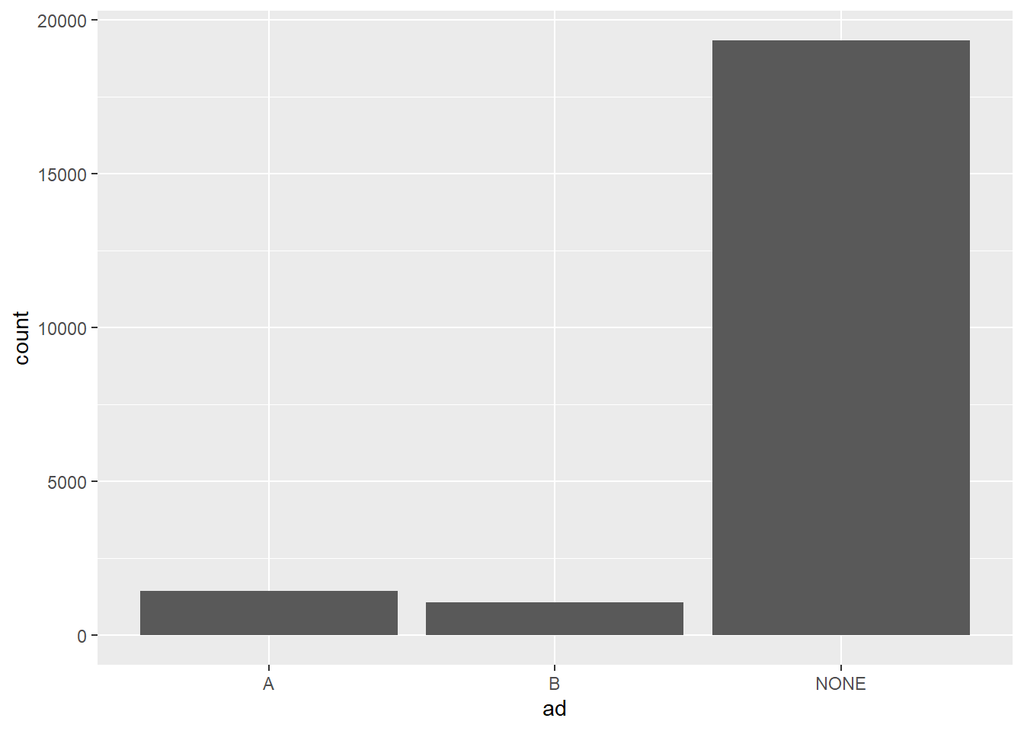

```r
ggplot(data = full_df, mapping = aes(x = ad)) +
  geom_bar()
```

- graph matches the descriptive statistics; majority of observations do not have ads
- Ad type “A” is slightly more than type “B”

# 5 Multi-variate non-graphical analysis

## 5.1 Categorical Variables

### 5.1.1 Promos by brand

Check sample sizes within each brand. Look at proportion of promo observations within each brand and compare across brands. Do some brands have a higher proportion of promos than others?

```r
# Counts of promotional v. non-promotional observations
full_df %>%
  tabyl(brand, promo) %>%
  adorn_totals(where = c("row", "col"))
```

```
##                          brand     0    1 Total
##         GENERAL MILLS CHEERIOS  1240  218  1458
##  GENERAL MILLS CINNAMON TST CR  1537  297  1834
##      GENERAL MILLS COCOA PUFFS   769  251  1020
##              GENERAL MILLS KIX   997  199  1196
##     GENERAL MILLS LUCKY CHARMS  1366  315  1681
##        KELLOGGS COCOA KRISPIES   647  234   881
##           KELLOGGS FROOT LOOPS  1673  519  2192
##        KELLOGGS FROSTED FLAKES  1819  476  2295
##   KELLOGGS FROSTED MINI WHEATS  1248  326  1574
##           KELLOGGS RAISIN BRAN  1060  206  1266
##         KELLOGGS RICE KRISPIES  1162  288  1450
##           KELLOGGS SMART START   812  322  1134
##             KELLOGGS SPECIAL K  1049  342  1391
##                POST GRAPE NUTS  1002  287  1289
##            POST SHREDDED WHEAT   924  265  1189
##                          Total 17305 4545 21850
```

```r
# Proportions of promotional v. non-promotional within brands
full_df %>%
  tabyl(brand, promo) %>%
  adorn_totals(where = c("row", "col")) %>%
  adorn_percentages(denominator = "row") %>%
  adorn_rounding(digits = 2)
```

```
##                          brand    0    1 Total
##         GENERAL MILLS CHEERIOS 0.85 0.15     1
##  GENERAL MILLS CINNAMON TST CR 0.84 0.16     1
##      GENERAL MILLS COCOA PUFFS 0.75 0.25     1
##              GENERAL MILLS KIX 0.83 0.17     1
##     GENERAL MILLS LUCKY CHARMS 0.81 0.19     1
##        KELLOGGS COCOA KRISPIES 0.73 0.27     1
##           KELLOGGS FROOT LOOPS 0.76 0.24     1
##        KELLOGGS FROSTED FLAKES 0.79 0.21     1
##   KELLOGGS FROSTED MINI WHEATS 0.79 0.21     1
##           KELLOGGS RAISIN BRAN 0.84 0.16     1
##         KELLOGGS RICE KRISPIES 0.80 0.20     1
##           KELLOGGS SMART START 0.72 0.28     1
##             KELLOGGS SPECIAL K 0.75 0.25     1
##                POST GRAPE NUTS 0.78 0.22     1
##            POST SHREDDED WHEAT 0.78 0.22     1
##                          Total 0.79 0.21     1
```

- counts and sample sizes look fine for each brand, but watch counts for any addt’l cross-tabs
- proportion of promos pretty similar across brands, but with some clusters of high and low values
- brands with highest proportion of promos (>=0.25):
  - cocoa puffs, cocoa krispies, smart start, special k
- brands with lowest proportion of promos (<=0.20):
  - cheerios, cinnamon toast, kix, lucky charms, raisin bran
- what do these groupings have in common?

### 5.1.2 Ad type by brand

```r
# Counts of observations for ad types A, B, and NONE by brand
full_df %>%
  tabyl(brand, ad) %>%
  adorn_totals(where = c("row", "col"))
```

```
##                          brand    A    B  NONE Total
##         GENERAL MILLS CHEERIOS   79   44  1335  1458
##  GENERAL MILLS CINNAMON TST CR  114   51  1669  1834
##      GENERAL MILLS COCOA PUFFS   76   54   890  1020
##              GENERAL MILLS KIX   70   54  1072  1196
##     GENERAL MILLS LUCKY CHARMS  103   69  1509  1681
##        KELLOGGS COCOA KRISPIES   52   37   792   881
##           KELLOGGS FROOT LOOPS  153  108  1931  2192
##        KELLOGGS FROSTED FLAKES  141  124  2030  2295
##   KELLOGGS FROSTED MINI WHEATS  127   88  1359  1574
##           KELLOGGS RAISIN BRAN   67   47  1152  1266
##         KELLOGGS RICE KRISPIES  114   88  1248  1450
##           KELLOGGS SMART START  124   90   920  1134
##             KELLOGGS SPECIAL K  125   82  1184  1391
##                POST GRAPE NUTS   46   63  1180  1289
##            POST SHREDDED WHEAT   65   62  1062  1189
##                          Total 1456 1061 19333 21850
```

```r
# Use for graphing?
# full_df %>%
#   group_by(brand, ad) %>%
#   summarise(n = n()) %>%
#   pivot_wider(names_from = ad, values_from = n)
```

- sample sizes are a bit lower for ad types A and B but still >30
- for each brand, the majority have no ads; what are the differences between ad types A and B?

```r
# Proportions for ad types A, B, excluding NONE to better compare between ads
full_df %>%
  filter(ad != "NONE") %>%
  tabyl(brand, ad) %>%
  adorn_totals(where = c("row", "col")) %>%
  adorn_percentages(denominator = "row") %>%
  adorn_rounding(digits = 2)
```

```
##                          brand    A    B NONE Total
##         GENERAL MILLS CHEERIOS 0.64 0.36    0     1
##  GENERAL MILLS CINNAMON TST CR 0.69 0.31    0     1
##      GENERAL MILLS COCOA PUFFS 0.58 0.42    0     1
##              GENERAL MILLS KIX 0.56 0.44    0     1
##     GENERAL MILLS LUCKY CHARMS 0.60 0.40    0     1
##        KELLOGGS COCOA KRISPIES 0.58 0.42    0     1
##           KELLOGGS FROOT LOOPS 0.59 0.41    0     1
##        KELLOGGS FROSTED FLAKES 0.53 0.47    0     1
##   KELLOGGS FROSTED MINI WHEATS 0.59 0.41    0     1
##           KELLOGGS RAISIN BRAN 0.59 0.41    0     1
##         KELLOGGS RICE KRISPIES 0.56 0.44    0     1
##           KELLOGGS SMART START 0.58 0.42    0     1
##             KELLOGGS SPECIAL K 0.60 0.40    0     1
##                POST GRAPE NUTS 0.42 0.58    0     1
##            POST SHREDDED WHEAT 0.51 0.49    0     1
##                          Total 0.58 0.42    0     1
```

- roughly a 60/40 split between ad types A and B, with most brands favoring ad type A
- exception is Post Grape Nuts, which favors ad type B
- does ad A yield better sales across brands?

### 5.1.3 Flavor by company

```r
# Counts of observations by company and flavor
full_df %>%
  tabyl(flavor, company) %>%
  adorn_totals(where = c("row", "col"))
```

```
##          flavor General Mills Kellogg Post Total
##  CINNAMON TOAST          1834       0    0  1834
##           COCOA          1020     881    0  1901
##           FRUIT             0    2192    0  2192
##         REGULAR          1203    5135 2478  8816
##         TOASTED          3132    3975    0  7107
##           Total          7189   12183 2478 21850
```

```r
# Proportions as percentage of flavor total
full_df %>%
  tabyl(flavor, company) %>%
  adorn_totals(where = c("row", "col")) %>%
  adorn_percentages(denominator = "row") %>%
  adorn_rounding(digits = 2)
```

```
##          flavor General Mills Kellogg Post Total
##  CINNAMON TOAST          1.00    0.00 0.00     1
##           COCOA          0.54    0.46 0.00     1
##           FRUIT          0.00    1.00 0.00     1
##         REGULAR          0.14    0.58 0.28     1
##         TOASTED          0.44    0.56 0.00     1
##           Total          0.33    0.56 0.11     1
```

```r
# Use for graphing?
# full_df %>%
#   group_by(company, flavor) %>%
#   summarise(n = n()) %>%
#   pivot_wider(names_from = company, values_from = n)
```

### 5.1.4 Sales by company and brand

```r
# Sales volume and dollar amount by company
full_df %>%
  group_by(company) %>%
  summarise(units_sold = sum(units),
            p_units = sum(promo * units),
            percent_p_units = (round(p_units/units_sold,4)*100),
            total_sales = sum(total_sales),
            p_sales = sum(promo * units * price),
            percent_p_sales = round(p_sales/total_sales, 4)*100) %>%
  arrange(desc(percent_p_units))
```

```
## # A tibble: 3 x 7
##   company units_sold p_units percent_p_units total_sales p_sales
##   <fct>        <int>   <int>           <dbl>       <dbl>   <dbl>
## 1 Kellogg     102512   30269            29.5     364579.  88336.
## 2 Post         15921    4657            29.2      56349.  13116.
## 3 Genera~      69017   15963            23.1     256689.  46294.
## # ... with 1 more variable: percent_p_sales <dbl>
```

```r
# Sales volume and dollar amount by brand -- graph with fill = company to differentiate brands?
full_df %>%
  group_by(brand) %>%
  summarise(total_sales = sum(total_sales),
            p_sales = sum(promo * units * price), # sales that had promos
            percent_p_sales = round(p_sales/total_sales, 4)*100) %>%
  arrange(desc(total_sales))
```

```
## # A tibble: 15 x 4
##    brand                         total_sales p_sales percent_p_sales
##    <fct>                               <dbl>   <dbl>           <dbl>
##  1 KELLOGGS FROSTED FLAKES            76550.  17303.            22.6
##  2 GENERAL MILLS CHEERIOS             74637.   9728.            13.0
##  3 GENERAL MILLS CINNAMON TST CR      62638.  10995.            17.5
##  4 GENERAL MILLS LUCKY CHARMS         60884.  12575.            20.6
##  5 KELLOGGS FROSTED MINI WHEATS       55314.  11457.            20.7
##  6 KELLOGGS RICE KRISPIES             50754.  11630.            22.9
##  7 KELLOGGS SPECIAL K                 49198.  12094.            24.6
##  8 KELLOGGS RAISIN BRAN               46859.   9166.            19.6
##  9 KELLOGGS FROOT LOOPS               45200.  13219.            29.2
## 10 POST GRAPE NUTS                    33564.   7384.            22
## 11 GENERAL MILLS KIX                  32273.   5456.            16.9
## 12 GENERAL MILLS COCOA PUFFS          26257.   7541.            28.7
## 13 KELLOGGS SMART START               25754.   8816.            34.2
## 14 POST SHREDDED WHEAT                22785.   5732.            25.2
## 15 KELLOGGS COCOA KRISPIES            14950.   4651.            31.1
```

- General Mills has the lowest percentage of promotional sales (both in units sold and total sales), but second highest in total dollar amount
- Total sales appears to be positively correlated with total units sold; more units sold always yields higher sales
- Some brands have a higher proportion of sales from promotions; generally, ones with the highest proportion of promotional sales have lowest total sales, with Kix as the exception

### 5.1.5 Sales across time period, overall and by brand or company

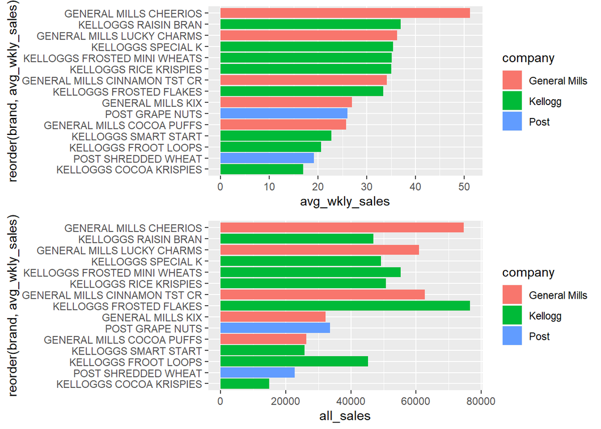

```r
grid.arrange(
full_df %>%
  group_by(brand, company) %>%
  summarize(avg_wkly_sales = mean(total_sales),
            all_sales = sum(total_sales)) %>%
  ggplot(mapping = aes(x = reorder(brand, avg_wkly_sales)
                       , y = avg_wkly_sales, fill = company)) +
  geom_bar(stat = 'identity') +
  coord_flip(),
full_df %>%
  group_by(brand, company) %>%
  summarize(avg_wkly_sales = mean(total_sales),
            all_sales = sum(total_sales)) %>%
  ggplot(mapping = aes(x = reorder(brand, avg_wkly_sales), y = all_sales, fill = company))+
  geom_bar(stat = 'identity')+
  coord_flip(),
ncol = 1)
```

Interesting the difference between the order between average weekly sales and total yearly sales. Are more stores selling ceratin brands like frosted flakes?

- Did sanity check on this group_by. Cheerios total sales is equal to avg_weekly * count (seen above in brand section) so method checks out. – Maybe there are more versions (UPCs) of some brands?

#### 5.1.5.1 Check how many versions of each brand

```r
full_df %>%
  group_by(brand) %>%
  summarize(n = n_distinct(UPC)) %>%
  arrange(desc(n))
```

```
## # A tibble: 15 x 2
##    brand                             n
##    <fct>                         <int>
##  1 KELLOGGS FROOT LOOPS             20
##  2 KELLOGGS FROSTED FLAKES          18
##  3 GENERAL MILLS LUCKY CHARMS       10
##  4 GENERAL MILLS CINNAMON TST CR     9
##  5 GENERAL MILLS CHEERIOS            7
##  6 KELLOGGS FROSTED MINI WHEATS      7
##  7 GENERAL MILLS COCOA PUFFS         6
##  8 GENERAL MILLS KIX                 6
##  9 KELLOGGS RICE KRISPIES            6
## 10 KELLOGGS SPECIAL K                6
## 11 POST GRAPE NUTS                   6
## 12 KELLOGGS COCOA KRISPIES           5
## 13 POST SHREDDED WHEAT               4
## 14 KELLOGGS RAISIN BRAN              2
## 15 KELLOGGS SMART START              2
```

Above table confirms suspision. There are more unique versions (UPCs) of some cereals such as Froot Loops and Frosted Flakes.

### 5.1.6 Sales by season

```r
# Total sales by company and season
full_df %>%
  group_by(company, season) %>%
  summarise(sales = sum(total_sales)) %>%
  pivot_wider(names_from = season, values_from = sales)
```

```
## # A tibble: 3 x 5
## # Groups:   company [3]
##   company          `1`    `2`     `3`    `4`
##   <fct>          <dbl>  <dbl>   <dbl>  <dbl>
## 1 General Mills 66602. 70191.  65618. 54279.
## 2 Kellogg       88945. 97033. 100738. 77863.
## 3 Post          15504. 16359.  14701.  9785.
```

```r
# Total sales by brand and season
full_df %>%
  group_by(brand, season) %>%
  summarise(sales = sum(total_sales)) %>%
  pivot_wider(names_from = season, values_from = sales)
```

```
## # A tibble: 15 x 5
## # Groups:   brand [15]
##    brand                            `1`    `2`    `3`    `4`
##    <fct>                          <dbl>  <dbl>  <dbl>  <dbl>
##  1 GENERAL MILLS CHEERIOS        19683. 19465. 18283. 17207.
##  2 GENERAL MILLS CINNAMON TST CR 15929. 18125. 16976. 11608.
##  3 GENERAL MILLS COCOA PUFFS      7497.  7011.  6919.  4830.
##  4 GENERAL MILLS KIX              6716.  8664.  8763.  8130.
##  5 GENERAL MILLS LUCKY CHARMS    16777. 16927. 14676. 12504.
##  6 KELLOGGS COCOA KRISPIES        2143.  2942.  6168.  3696.
##  7 KELLOGGS FROOT LOOPS           9917. 11206. 13092. 10984.
##  8 KELLOGGS FROSTED FLAKES       20235. 20714. 20098. 15504.
##  9 KELLOGGS FROSTED MINI WHEATS  13262. 15316. 16148. 10588.
## 10 KELLOGGS RAISIN BRAN          12513. 12557. 12293.  9496.
## 11 KELLOGGS RICE KRISPIES        12164. 13525. 13054. 12011.
## 12 KELLOGGS SMART START           6845.  7681.  6540.  4689.
## 13 KELLOGGS SPECIAL K            11865. 13092. 13345. 10896.
## 14 POST GRAPE NUTS                9629.  9720.  8783.  5432.
## 15 POST SHREDDED WHEAT            5875.  6639.  5917.  4353.
```

```r
# Total sales by flavor and season
full_df %>%
  group_by(flavor, season) %>%
  summarise(sales = sum(total_sales)) %>%
  pivot_wider(names_from = season, values_from = sales)
```

```
## # A tibble: 5 x 5
## # Groups:   flavor [5]
##   flavor            `1`    `2`    `3`    `4`
##   <fct>           <dbl>  <dbl>  <dbl>  <dbl>
## 1 CINNAMON TOAST 15929. 18125. 16976. 11608.
## 2 COCOA           9640.  9953. 13088.  8526.
## 3 FRUIT           9917. 11206. 13092. 10984.
## 4 REGULAR        68230. 73613. 72171. 53518.
## 5 TOASTED        67333. 70686. 65730. 57291.
```

- sales seem to drop in season 4

### 5.1.7 Sales by flavor

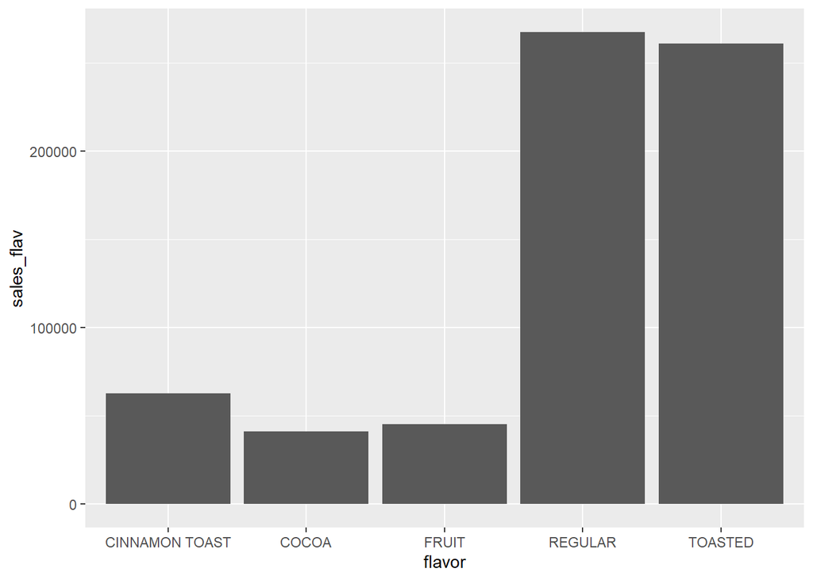

```r
full_df %>%
  group_by(flavor) %>%
  summarize(sales_flav = sum(total_sales)) %>%
  ggplot(mapping = aes(x = flavor, y = sales_flav)) +
    geom_bar(stat = 'identity')
```

## 5.2 Quantitative Variables

Correlation table of quantitative variables

```r
full_df %>%
  select_if(is.numeric) %>%
  cor() %>%
  round(2)
```

```
##              store_key  week units price promo volume total_sales season
## store_key         1.00  0.01  0.03 -0.01 -0.02  -0.01        0.03   0.01
## week              0.01  1.00 -0.03  0.03 -0.02  -0.02       -0.02   0.97
## units             0.03 -0.03  1.00 -0.19  0.20   0.02        0.91  -0.03
## price            -0.01  0.03 -0.19  1.00 -0.41   0.54        0.15   0.03
## promo            -0.02 -0.02  0.20 -0.41  1.00  -0.05        0.03  -0.01
## volume           -0.01 -0.02  0.02  0.54 -0.05   1.00        0.20  -0.02
## total_sales       0.03 -0.02  0.91  0.15  0.03   0.20        1.00  -0.02
## season            0.01  0.97 -0.03  0.03 -0.01  -0.02       -0.02   1.00
## ad2              -0.01 -0.07  0.13 -0.19  0.32  -0.03        0.03  -0.07
## total_volume      0.03 -0.04  0.87  0.04  0.15   0.41        0.90  -0.04
##                ad2 total_volume
## store_key    -0.01         0.03
## week         -0.07        -0.04
## units         0.13         0.87
## price        -0.19         0.04
## promo         0.32         0.15
## volume       -0.03         0.41
## total_sales   0.03         0.90
## season       -0.07        -0.04
## ad2           1.00         0.09
## total_volume  0.09         1.00
```

- moderately strong correlations:
  - negative association between price and promo; correlation = -0.41
  - positive association between price and volume; correlation = 0.54
- weak correlations:
  - positive associaton between promo and units: correlation = 0.2

# 6 Multi-variate graphical analysis

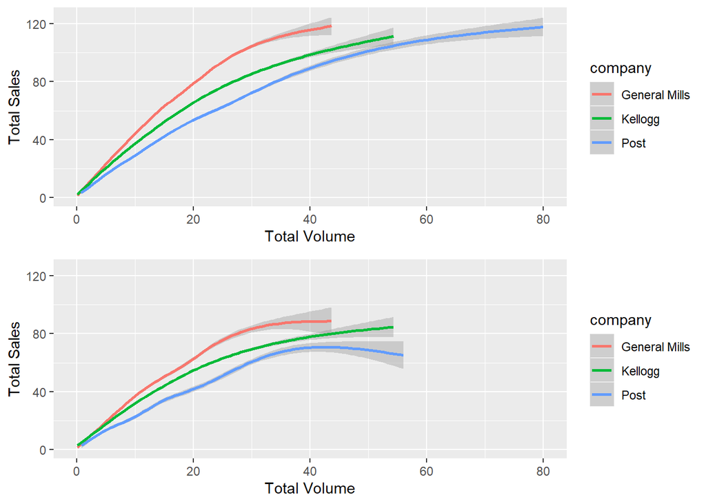

```r
#interested in price/volume between promo and no promo for each company
grid.arrange(
  full_df[full_df$promo == 0,] %>%
    ggplot(mapping = aes(x = volume * units, y = total_sales, color = company)) +
    geom_smooth() +
    scale_x_continuous('Total Volume', limits = c(0,80)) +
    scale_y_continuous('Total Sales', limits = c(0, 125)),

  full_df[full_df$promo == 1,] %>%
    ggplot(mapping = aes(x = volume * units, y = total_sales, color = company)) +
    geom_smooth() +
    scale_x_continuous('Total Volume',limits = c(0,80)) +
    scale_y_continuous('Total Sales', limits = c(0, 125)),

  ncol = 1
)
```

GM is getting beat on Price/Volume in both promo and non-promo sales

## 6.1 Categorical Variables

### 6.1.1 Sales comparison across promotions

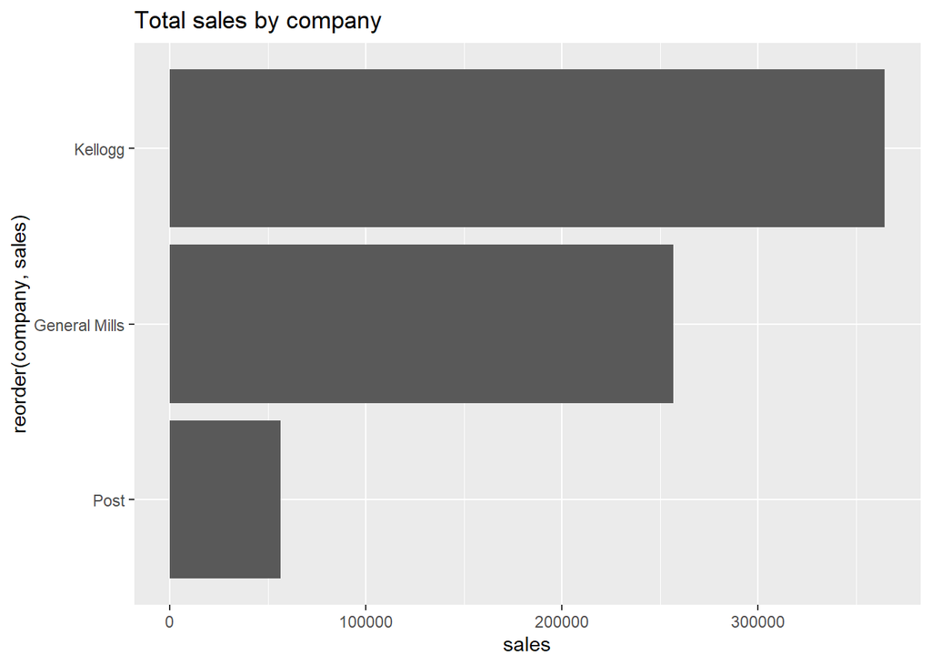

```r
# Comparing sales across companies
full_df %>%
  group_by(company) %>%
  summarise(sales = sum(total_sales)) %>%
  ggplot(mapping = aes(x = reorder(company, sales), y = sales)) +
  geom_col() +
  coord_flip() +
  labs(title = "Total sales by company")
```

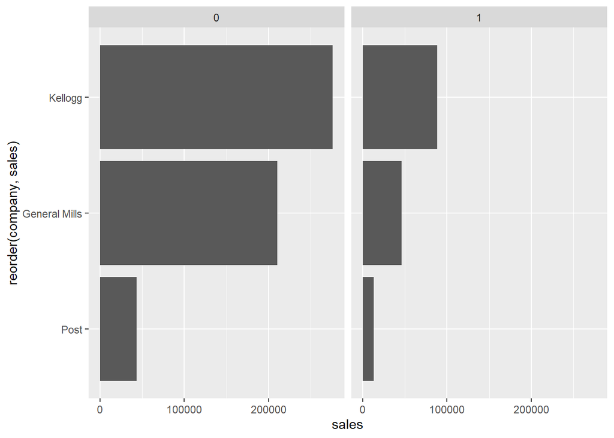

```r
# Sales comparison with and without promos
full_df %>%
  group_by(company, promo) %>%
  summarise(sales = sum(total_sales)) %>%
  ggplot(mapping = aes(x = reorder(company, sales), y = sales, group = promo)) +
  geom_col() +
  coord_flip() +
  facet_grid(. ~ promo)
```

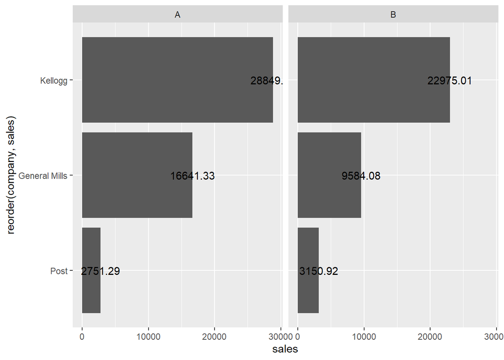

```r
# Sales comparison with and without ads
# Excluding those without ads to more easily compare ad categories A and B
full_df %>%
  group_by(company, ad) %>%
  filter(ad != "NONE") %>%
  summarise(sales = sum(total_sales)) %>%
  ggplot(mapping = aes(x = reorder(company, sales), y = sales, group = ad)) +
  geom_col() +
  geom_text(aes(label = sales)) +
  coord_flip() +
  facet_grid(. ~ ad)
```

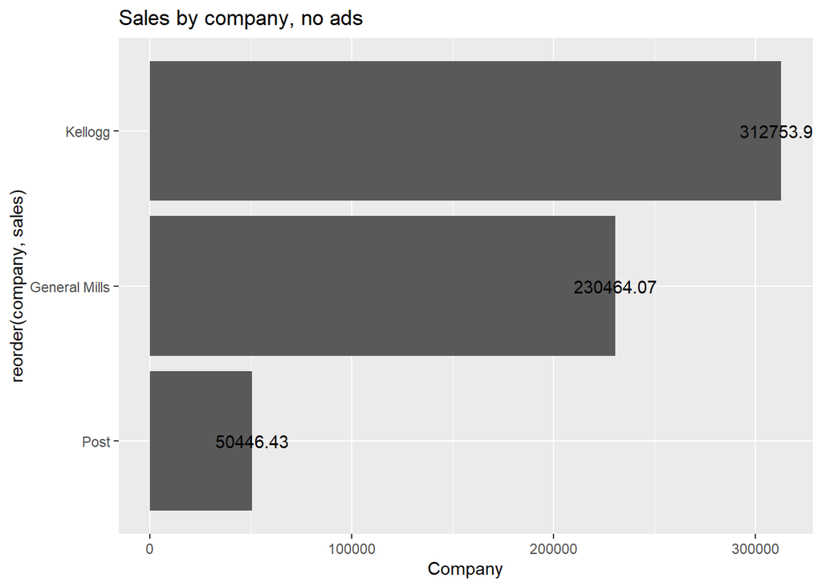

```r
# Sales comparison only for products without ads
full_df %>%
  group_by(company, ad) %>%
  filter(ad == "NONE") %>%
  summarise(sales = sum(total_sales)) %>%
  ggplot(mapping = aes(x = reorder(company, sales), y = sales)) +
  geom_col() +
  coord_flip() +
  geom_text(aes(label = sales)) +
  labs(title = "Sales by company, no ads",
       y = "Company")
```

- When looking at total sales, sales with/without promos and with/without ads, Kellogg always has the highest, followed by General Mills and then Post. Assess for any changes to this pattern when looking at sales by brand.
- When there are ads, type “A” yields higher sales for Kellogg and General Mills while ad type “B” yields higher sales for Post.

### 6.1.2 Sales across brands by promotions and ads

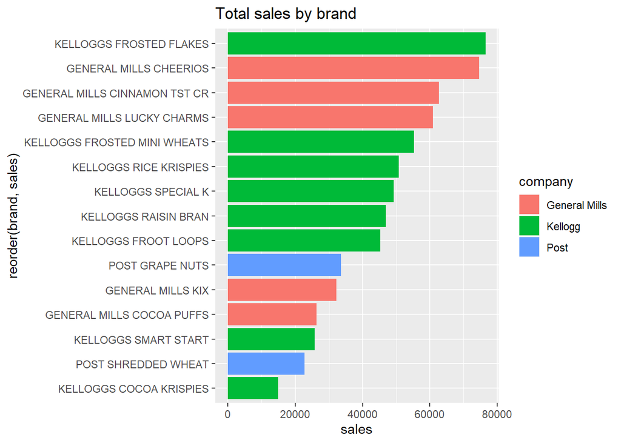

```r
# Comparing total sales across brands
full_df %>%
  group_by(brand, company) %>%
  summarise(sales = sum(total_sales)) %>%
  ggplot(mapping = aes(x = reorder(brand, sales), y = sales, fill = company)) +
  geom_col() +
  coord_flip() +
  labs(title = "Total sales by brand")
```

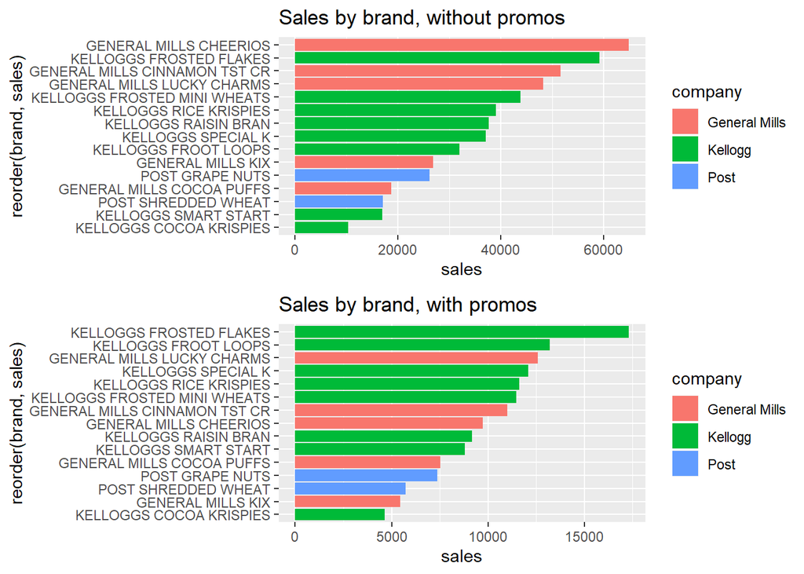

```r
# Sales comparison with and without promos
grid.arrange(
full_df %>%
  group_by(brand, company, promo) %>%
  filter(promo == 0) %>%
  summarise(sales = sum(total_sales)) %>%
  ggplot(mapping = aes(x = reorder(brand, sales), y = sales, fill = company)) +
  geom_col() +
  labs(title = "Sales by brand, without promos") +
  coord_flip(),
full_df %>%
  group_by(brand, company, promo) %>%
  filter(promo == 1) %>%
  summarise(sales = sum(total_sales)) %>%
  ggplot(mapping = aes(x = reorder(brand, sales), y = sales, fill = company)) +
  geom_col() +
  labs(title = "Sales by brand, with promos") +
  coord_flip(),
nrow = 2)
```

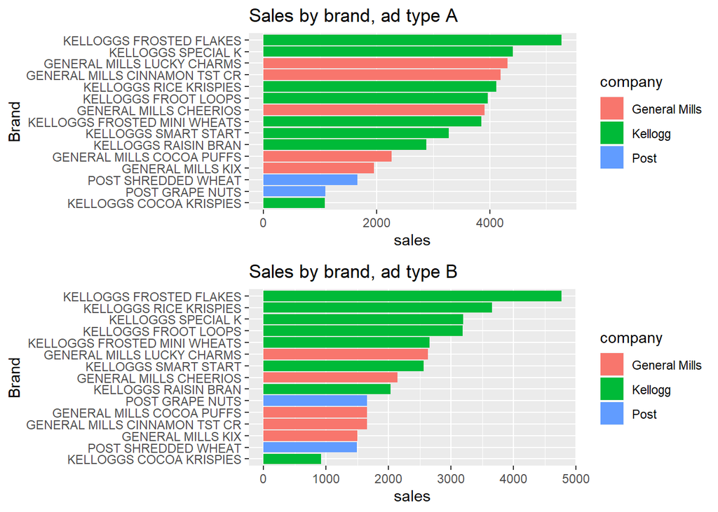

```r
# Sales comparison across ad types
# Excluding those without ads to more easily compare ad categories A and B
grid.arrange(
full_df %>%
  group_by(brand, company, ad) %>%
  filter(ad == "A") %>%
  summarise(sales = sum(total_sales)) %>%
  ggplot(mapping = aes(x = reorder(brand, sales), y = sales, fill = company)) +
  geom_col() +
  labs(title = "Sales by brand, ad type A",
       x = "Brand") +
  coord_flip(),
full_df %>%
  group_by(brand, company, ad) %>%
  filter(ad == "B") %>%
  summarise(sales = sum(total_sales)) %>%
  ggplot(mapping = aes(x = reorder(brand, sales), y = sales, fill = company)) +
  geom_col() +
  labs(title = "Sales by brand, ad type B",
       x = "Brand") +
  coord_flip(),
ncol = 1)
```

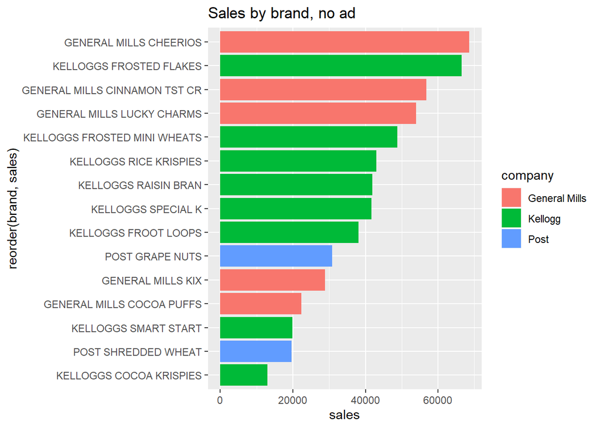

```r
# Sales comparison only for products without ads
full_df %>%
  group_by(brand, company, ad) %>%
  filter(ad == "NONE") %>%
  summarise(sales = sum(total_sales)) %>%
  ggplot(mapping = aes(x = reorder(brand, sales), y = sales, fill = company)) +
  geom_col() +
  labs(title = "Sales by brand, no ad") +
  coord_flip()
```

Total Sales

- For total sales, three General Mills brands are in the top 5 and two are in the bottom 5
- Does this same pattern hold across promos and ads?

Promotions

- Without promos, General Mills sales are higher relative to other brands
- With promos, General Mills sales are lower relative to other brands

Ads

- General Mills brands do worse relative to other brands with ad type “B”
- Also do better relative to other brands when there are no ads

### 6.1.3 Sales by Season

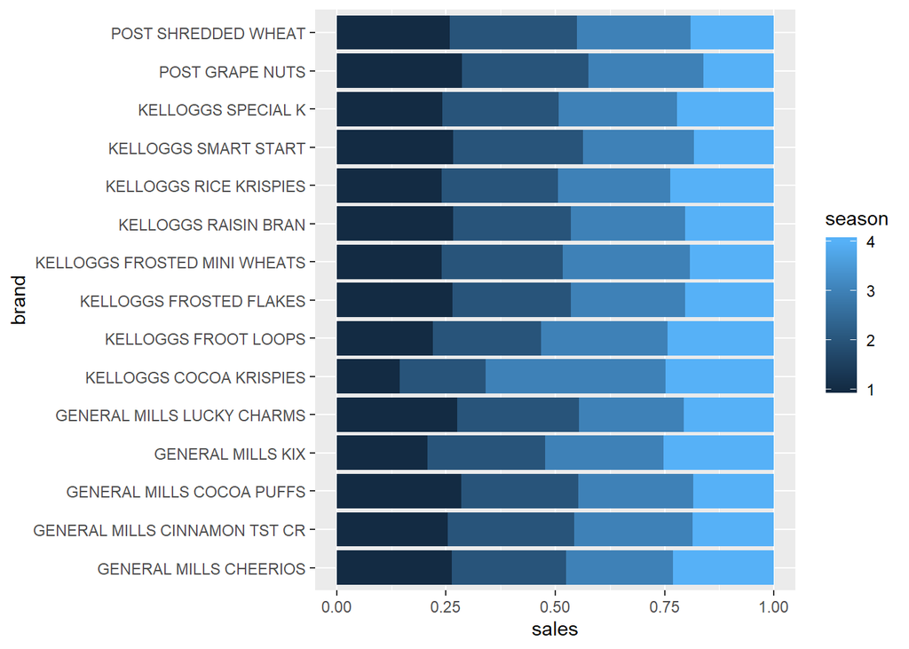

```r
# What is the proportion of sales attributed to each season within brand?
full_df %>%
  group_by(brand, season) %>%
  summarise(sales = sum(total_sales)) %>%
  ggplot(mapping = aes(x = brand, y = sales, fill = season)) +
  geom_col(position = "fill") +
  coord_flip()
```

### 6.1.4 Promos and Ads by Season for each company

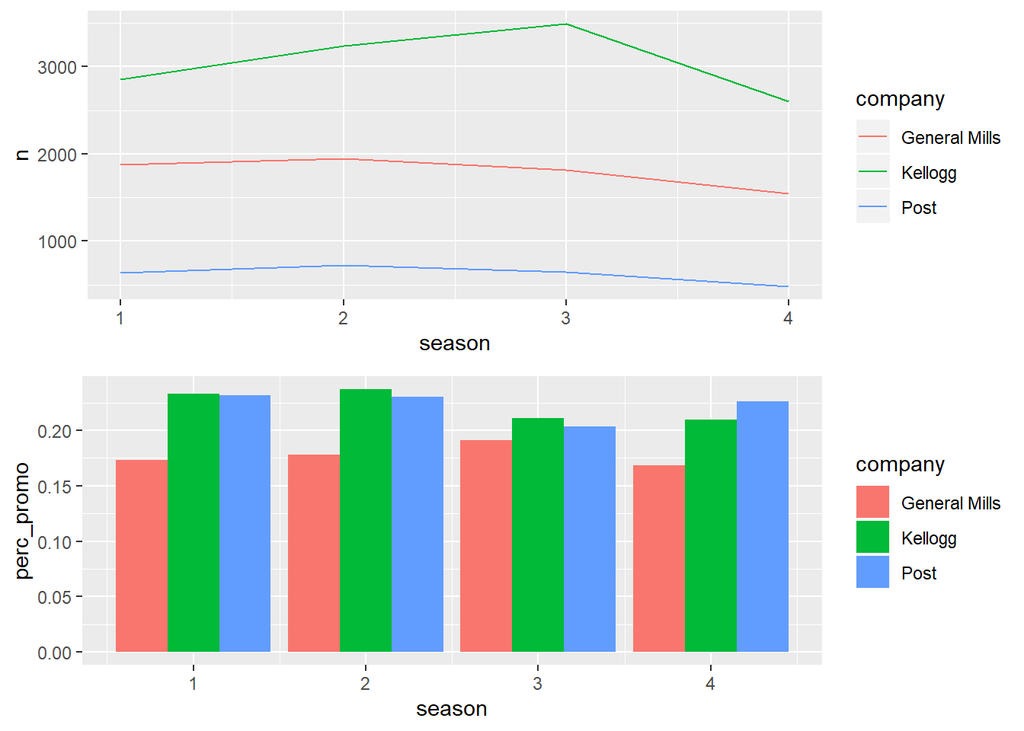

```r
#Do some companies run more promotions at certain times of year?
#Number of sales each season
# full_df %>%
#   ggplot(mapping = aes(x = season, fill = company)) +
#   geom_bar(position = 'dodge')
grid.arrange(
full_df %>%
  group_by(company,season) %>%
  summarize(n = n()) %>%
  ggplot(mapping = aes(x = season, y = n, color = company)) +
  geom_line(),
full_df %>%
  group_by(company, season) %>%
  summarize(n = n(), perc_promo = sum(promo)/n) %>%
  ggplot(mapping = aes(x = season, y = perc_promo, fill = company)) +
  geom_bar(position = 'dodge', stat = 'identity'),
ncol = 1
)
```

## 6.2 Quantitative Variables

### 6.2.1 Price and Total Volume

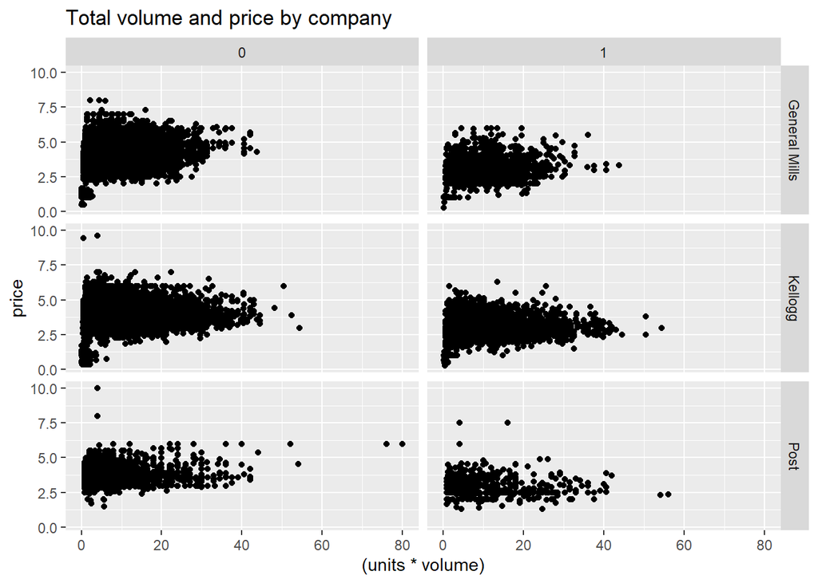

```r
# Scatterplots looking at relationships between price and total volume by company
full_df %>%
  ggplot(data = full_df, mapping = aes(x = (units*volume), y = price)) +
  geom_point() +
  labs(title = "Total volume and price by company") +
  facet_grid(company~promo)
```

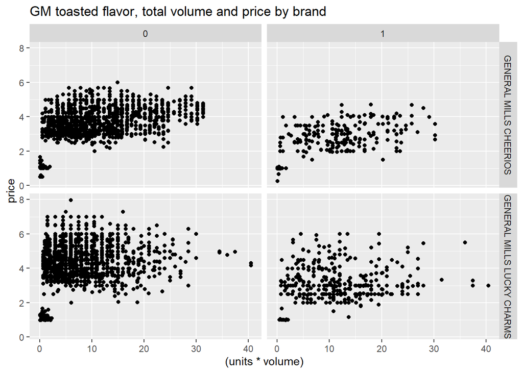

```r
# Scatterplots looking at relationships between price and total volume for GM Toasted brands
full_df %>%
  filter(flavor == "TOASTED", company == "General Mills") %>%
  ggplot(mapping = aes(x = (units*volume), y = price)) +
  geom_point() +
  labs(title = "GM toasted flavor, total volume and price by brand") +
  facet_grid(brand~promo)
```

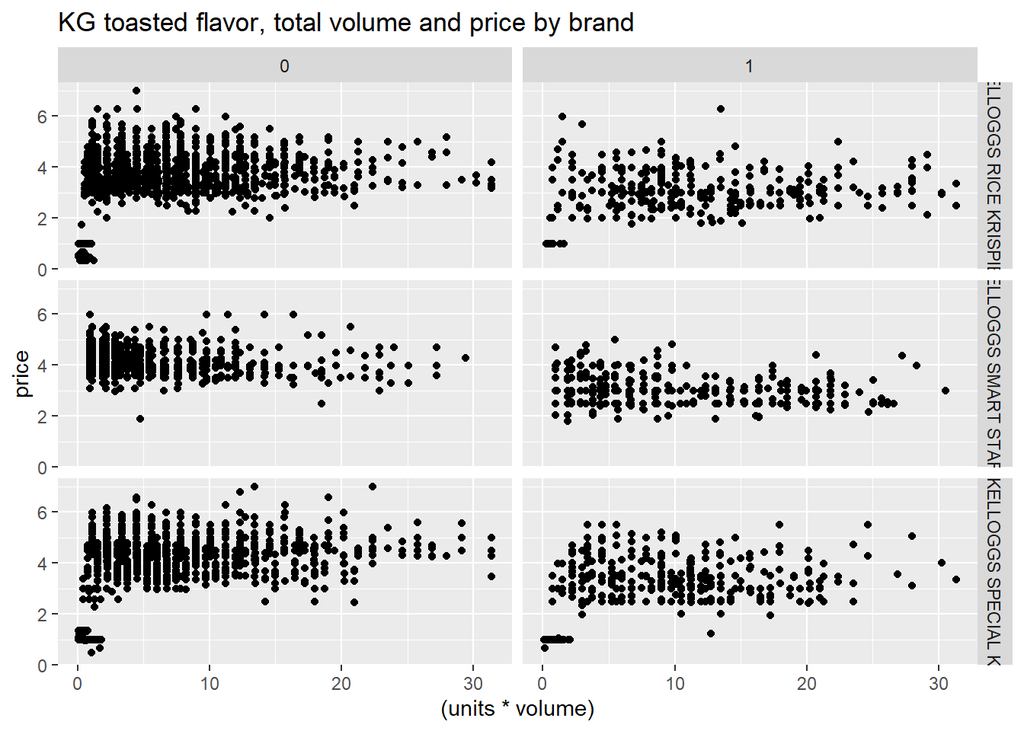

```r
# Scatterplots looking at relationships between price and total volume for KG Toasted brands
full_df %>%
  filter(flavor == "TOASTED", company == "Kellogg") %>%
  ggplot(mapping = aes(x = (units*volume), y = price)) +
  geom_point() +
  labs(title = "KG toasted flavor, total volume and price by brand") +
  facet_grid(brand~promo)
```

- No relationship between total volume and price
  - Expected to see lower prices at higher volumes, given the negative correlation between price and units
  - Price appears to stay within the same ranges across volumes and promo; no increase or decrease apparent

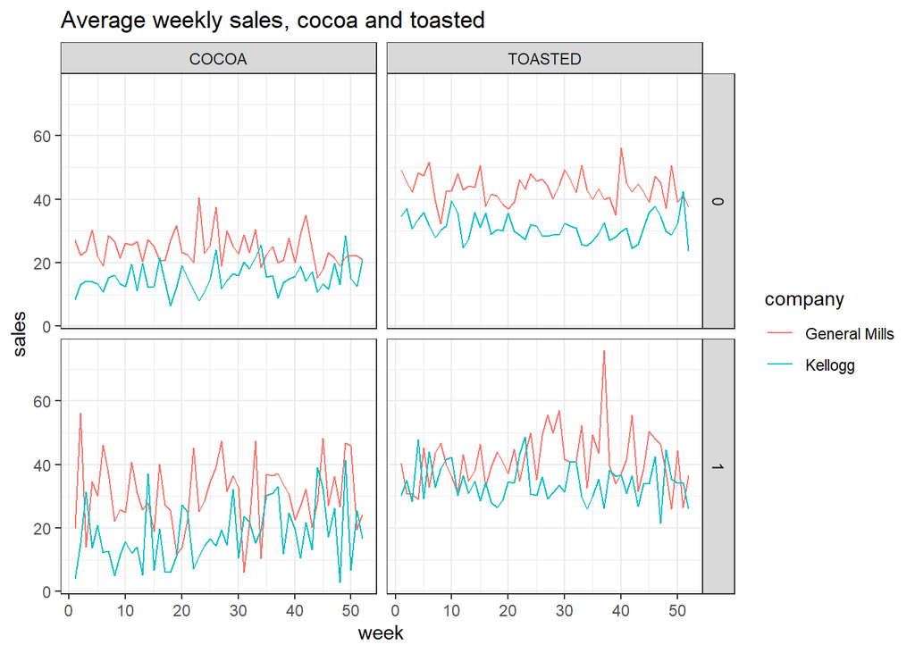

```r
# Avg sales by flavor and company, focus on General Mills and Kellogg
full_df %>%
  filter(flavor != "FRUIT", flavor != "CINNAMON TOAST", flavor != "REGULAR") %>%
  group_by(company, week, promo, flavor) %>%
  summarise(sales = mean(total_sales)) %>%
  ggplot(mapping = aes(x = week, y = sales, group = company, color = company)) +
  geom_line() +
  labs(title = "Average weekly sales, cocoa and toasted") +
  facet_grid(promo ~ flavor) +
  theme_bw()
```

- GM cocoa avg sales consistently higher with and w/out promo
- GM toasted avg sales higher w/out promo, gap closed w/promo

## 6.3 Categorical and Quantitative Variables

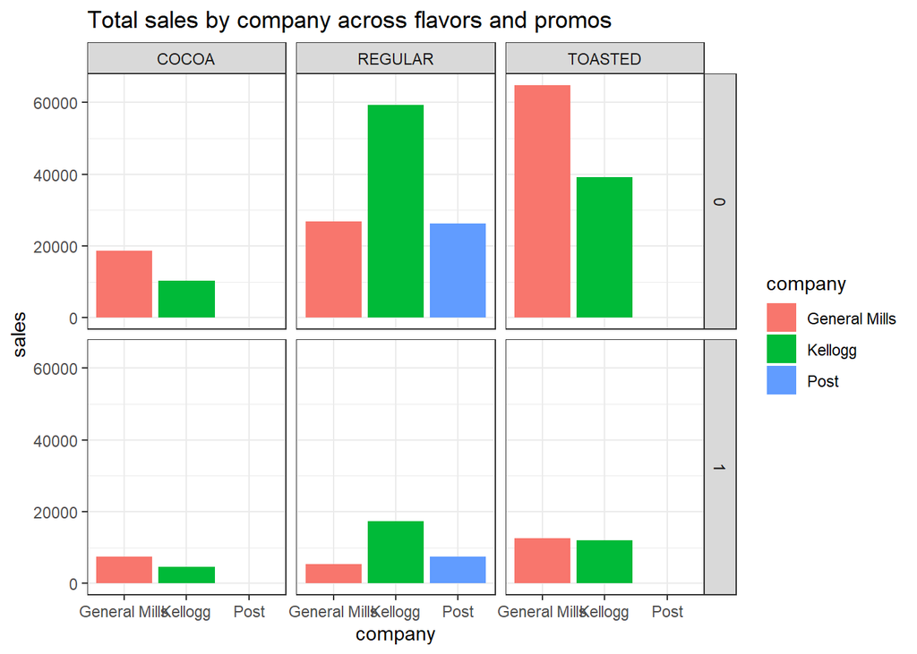

```r
# Total sales across seasons for promos vs. no promos across flavors
full_df %>%
  filter(flavor != "CINNAMON TOAST",
         flavor != "FRUIT") %>%
  group_by(company, promo, brand, flavor) %>%
  summarise(sales = sum(total_sales)) %>%
  ggplot(mapping = aes(x = company, y = sales, fill = company)) +
  geom_col(position = "dodge") +
  theme_bw() +
  labs(title = "Total sales by company across flavors and promos") +
  facet_grid(promo ~ flavor)
```

**Closer look at toasted flavor**

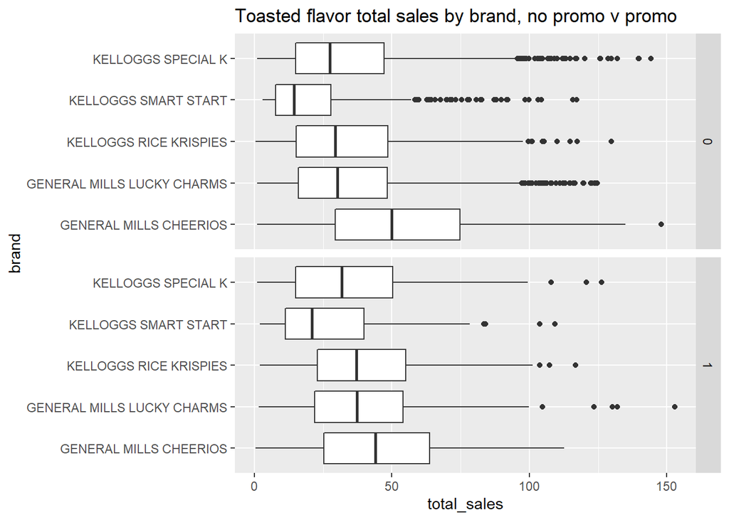

```r
# Total sales by brand for toasted flavor, promo v no promo
full_df %>%
  filter(flavor == "TOASTED") %>%
  group_by(brand, company, promo) %>%
  ggplot(mapping = aes(x = brand, y = total_sales)) +
  geom_boxplot() +
  coord_flip() +
  facet_grid(promo~.) +
  labs(title = "Toasted flavor total sales by brand, no promo v promo")
```

- Without promos, cheerios leads all brands with sales but is more even with other brands with promos
- Total sales for Cheerios seem to decrease with promos, while other brands increase

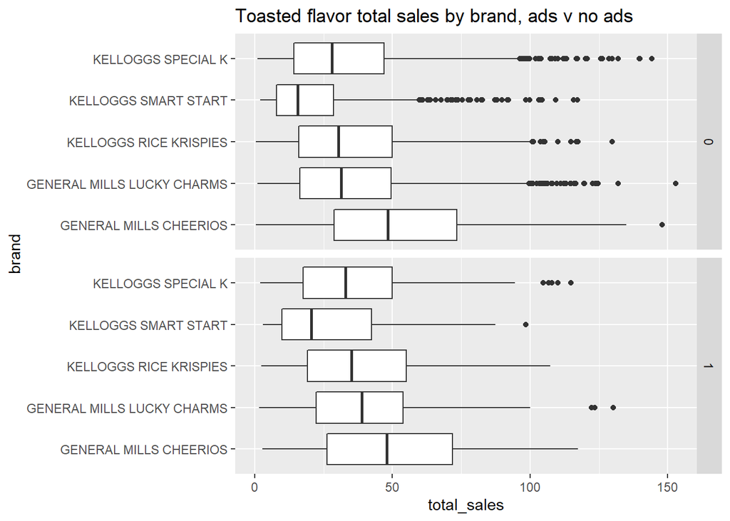

```r
# Total sales by brand for toasted flavor, advs v no ads
full_df %>%
  filter(flavor == "TOASTED") %>%
  group_by(brand, company, ad2) %>%
  ggplot(mapping = aes(x = brand, y = total_sales)) +
  geom_boxplot() +
  coord_flip() +
  facet_grid(ad2~.) +
  labs(title = "Toasted flavor total sales by brand, ads v no ads")
```

- Ads don’t seem to make a difference for Cheerios, but make a slight difference for Lucky Charms
- Seem to make more of a difference for Kellogg brands